# Homework-2

Author

Dheeraj Oruganty

## Problem-1

Consider the random variable defined by counting the number of failures until the first success, for independent trials with success probability $p$. Given $p$ between $0$ and $1$, the **R** commands `myattempts(p)` and `rgeom(1,p)` both simulate this random variable. Find a way of demonstrating that the two commands indeed give the same results, for five different values of p. *You may find the table() function useful.*

```r
set.seed(123)
mytoss = function(p){
  u <- runif(1)
  x <- as.numeric(u < p)#when p is the larger number, there is a higher chance of being this argument true.
  return(x)
}
myattempts = function(p){ counter <- 0
while (mytoss(p) == 0){ counter <- counter + 1 }
return(counter) }
```

Choose five p’s of your choice, e.g. $p \in \{.1, .3, .5, .7, .9\}$. Run `myattempts` and `rgeom` each 10000 times.

1. For the first p, store the fraction of outcomes in the simulation in the columns of a suitable data frame and compare (Hint: use 3 columns to compare `rgeom()`, `myattempts()` and `dgeom()` )

```r
set.seed(1000)

myattempts_df <- data.frame(replicate(10000, myattempts(0.5)))
myattempts_df<- data.frame(table(myattempts_df[, 1]))

rgeom_df <- data.frame(replicate(10000, rgeom(1,0.5)))
rgeom_df <- data.frame(table(rgeom_df[, 1]))

df_all <- merge(myattempts_df, rgeom_df, by = "Var1", sort = FALSE)

df_all$Var1 <- as.integer(df_all$Var1)-1

x <- as.integer(df_all$Var1)
x
```

```
 [1]  0  1  2  3  4  5  6  7  8  9 10 11 12
```

```r
df_dgeom <- data.frame(dgeom(x,0.5))

df_all <- cbind(df_all, df_dgeom)

df_all$Freq.x <- df_all$Freq.x/10000
df_all$Freq.y <- df_all$Freq.y/10000
df_all
```

```
   Var1 Freq.x Freq.y dgeom.x..0.5.
1     0 0.5026 0.4978  0.5000000000
2     1 0.2484 0.2517  0.2500000000
3     2 0.1236 0.1261  0.1250000000
4     3 0.0630 0.0609  0.0625000000
5     4 0.0288 0.0315  0.0312500000
6     5 0.0171 0.0170  0.0156250000
7     6 0.0092 0.0070  0.0078125000
8     7 0.0041 0.0046  0.0039062500
9     8 0.0022 0.0011  0.0019531250
10    9 0.0006 0.0011  0.0009765625
11   10 0.0001 0.0007  0.0004882812
12   11 0.0001 0.0002  0.0002441406
13   12 0.0002 0.0001  0.0001220703
```

2. For the second p, Compare distribution by computing statistics such as mean and standard deviation.

```r
meanmyattempts <- mean(replicate(1000,myattempts(0.7)))
sdmyattempts <- sd(replicate(1000,myattempts(0.7)))


meanrgeom <- mean(replicate(1000,rgeom(1,0.7)))
sdrgeom <- sd(replicate(1000,rgeom(1,0.7)))


df1 <- data.frame(
    myattempt <- c(meanmyattempts,sdmyattempts),
    rgeom <- c(meanrgeom,sdrgeom))

rownames(df1) <- c("Mean", "Standard deviation")

colnames(df1) <- c("Myattempts", "Rgeom")

df1
```

```
                   Myattempts     Rgeom
Mean                0.4360000 0.4330000
Standard deviation  0.7787152 0.8619129
```

3. For the third p, plot both distributions as histograms in the same plot.

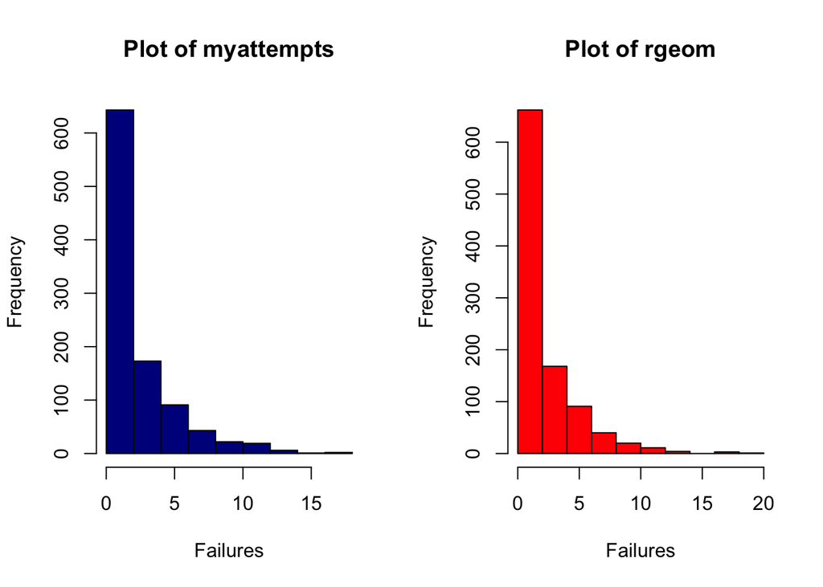

```r
library(ggplot2)
par(mfrow = c(1,2))
hist(replicate(1000,myattempts(0.3)), col = 'darkblue', main = 'Plot of myattempts', xlab = 'Failures', ylab = 'Frequency')

hist(replicate(1000,rgeom(1,0.3)), col = 'Red', main = 'Plot of rgeom', xlab = 'Failures', ylab = 'Frequency')
```

```r
par(mfrow = c(1,1))
```

4. For the fourth p, make side-by-side box plots.

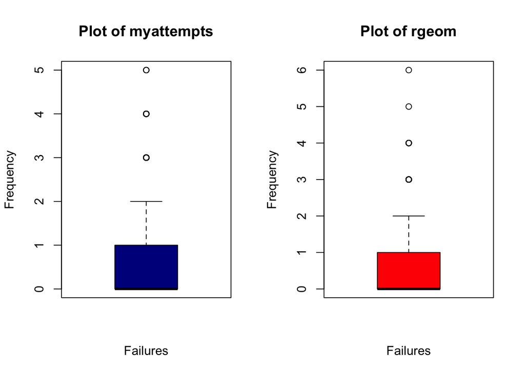

```r
par(mfrow = c(1,2))
boxplot(replicate(1000,myattempts(0.63)), col = 'darkblue', main = 'Plot of myattempts', xlab = 'Failures', ylab = 'Frequency')

boxplot(replicate(1000,rgeom(1,0.63)), col = 'Red', main = 'Plot of rgeom', xlab = 'Failures', ylab = 'Frequency')
```

5. For the fifth p, plot the two empirical distribution functions in the same plot.

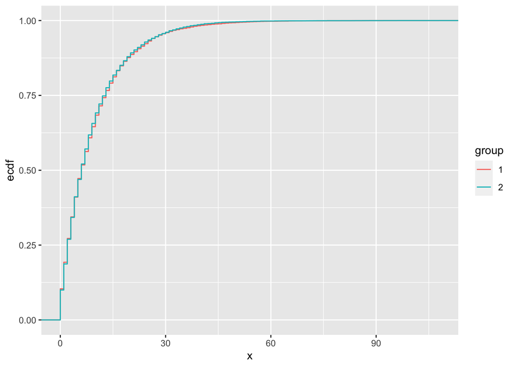

```r
# Defining the Data Frame for ECDF

df2 <- data.frame(x = c(replicate(10000,myattempts(0.1)), c(replicate(10000,rgeom(1,0.1)))), group = gl(2, 10000))


ggplot(df2, aes(x=x, col=group)) +

# stat_ecdf() function is used to plot ECDF plot
stat_ecdf()
```

## Problem-2

Consider the following random experiment: draw a uniformly distributed random number $X_1$ from the interval $(0,1)$. Next, draw a uniformly distributed random number $X_2$ from the interval $(0,1+X_1)$, a uniformly distributed random number $X_3$ from the interval $(0,1+X_2)$ and so on until $X_{20}$.

Use a monte carlo simulation to give an approximate answer to What is the mean value of $X_{20}$? and use a histogram to identify the distribution of $X_{20}$.

$X_1 \sim unif(0,1)$ $X_2 \sim unif(0,1+X_1)$ $X_3 \sim unif(0,1+X_2)$ . . . $X_{20} \sim unif(0,1+X_{19})$

The **R** command for drawing a uniformly distributed random number from the interval $(0,b)$ is *runif(1,min = 0, max = b)*.

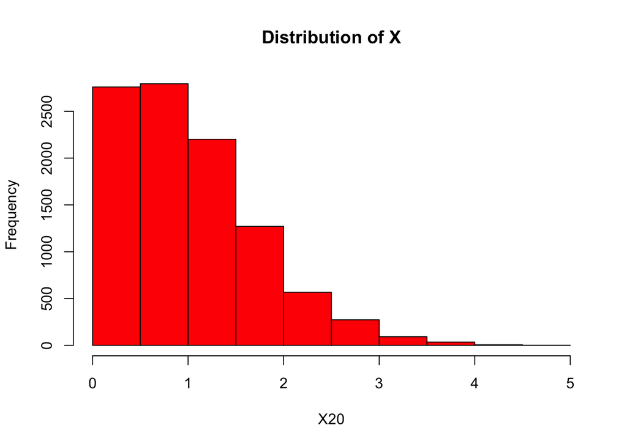

```r
nt <- 10000

# Initialize an empty vector to store X20 values
val <- numeric(nt)

# Perform the Monte Carlo simulation
for (i in 1:nt) {
  X <- runif(1, min = 0, max = 1)
  for (j in 2:20) {
    X <- runif(1, min = 0, max = 1 + X)
  }
  val[i] <- X
}

meanval <- mean(val)


hist(val, main = "Distribution of X", xlab = "X20", col = "red")
```

```r
cat("Estimated mean of X(20):", meanval, "\n")
```

```
Estimated mean of X(20): 1.013484
```

## Problem-3

Suppose that the daily power consumption of a major city, $X$, has a Gamma distribution with shape parameter $r = 4$ and scale parameter $\rho = 2$. Use **R** to compute the following quantities: \

1. $Prob(X \le 12)$

```r
# exact
sh = 4
sc = 2

r = 4
rho = 2
prob1 <- pgamma(12, shape = sh, scale = sc)

cat("Prob(X > 12):", prob1, "\n")
```

[output not shown]

2. $Prob(X > 5)$

```r
# Probability that X is greater than 5
prob2 <- 1 - pgamma(5, shape = r, scale = rho)
cat("Prob(X > 5):", prob2, "\n")
```

```
Prob(X > 5): 0.7575761
```

3. $Prob(|X-8|) < 1$

```r
# Probability that |X - 8| < 1 (equivalent to 7 < X < 9)
prob3 <- pgamma(9, shape = r, scale = rho) - pgamma(7, shape = r, scale = rho)
cat("Prob(|X - 8| < 1):", prob3, "\n")
```

```
Prob(|X - 8| < 1): 0.1943367
```

4. $z$ such that $Prob(X < z) = .95$

```r
# z such that Prob(X < z) = 0.95
z <- qgamma(0.95, shape = r, scale = rho)
cat("z such that Prob(X < z) = 0.95:", z, "\n")
```

```
z such that Prob(X < z) = 0.95: 15.50731
```

(Hint:$|X-8| < 1$ is equivalent to $7 < X < 9$)

## Problem-4

Probability theory says that a binomial distribution, $B(n,p)$ is close to that of a normal distribution with mean $np$ and standard deviation $\sqrt{np(1-p)}$, if $np$ and $n(1-p)$ are both sufficiently large, e.g. at least 10.

Check this by plotting both cumulative distribution functions in the same figure, using a staircase plot for the binomial distribution and a line plot for the normal distribution, for three different cases: a case where both $np$ and $n(1-p)$ are large, a case where $np$ is large and $n(1-p) < 10$, and a case where $np < 10$ and $n(1-p) < 10$.

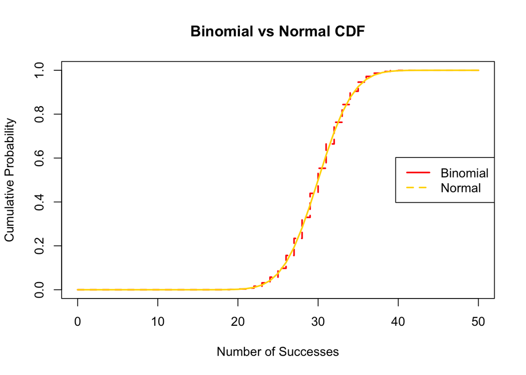

```r
# Function to plot binomial and normal CDFs
plot_cdf <- function(n, p) {
  x <- 0:n

  # Compute binomial CDF
  bicdf <- pbinom(x, size = n, prob = p)

  mu <- n * p
  sigma <- sqrt(n * p * (1 - p))

  # Compute normal CDF
  ncdf <- pnorm(x, mean = mu, sd = sigma)

  # Plotting
  plot(x, bicdf, type = "s", main = "Binomial vs Normal CDF",
       xlab = "Number of Successes", ylab = "Cumulative Probability",
       col = "red", lty = 2, lwd = 2)
  lines(x, ncdf, type = "l", col = "gold", lty = 1, lwd = 2)
  legend("right", legend = c("Binomial", "Normal"), col = c("red", "gold"), lty = 1:2, lwd = 2)
}

# Case 1: np and n(1-p) are both large
plot_cdf(n = 50, p = 0.6)
```

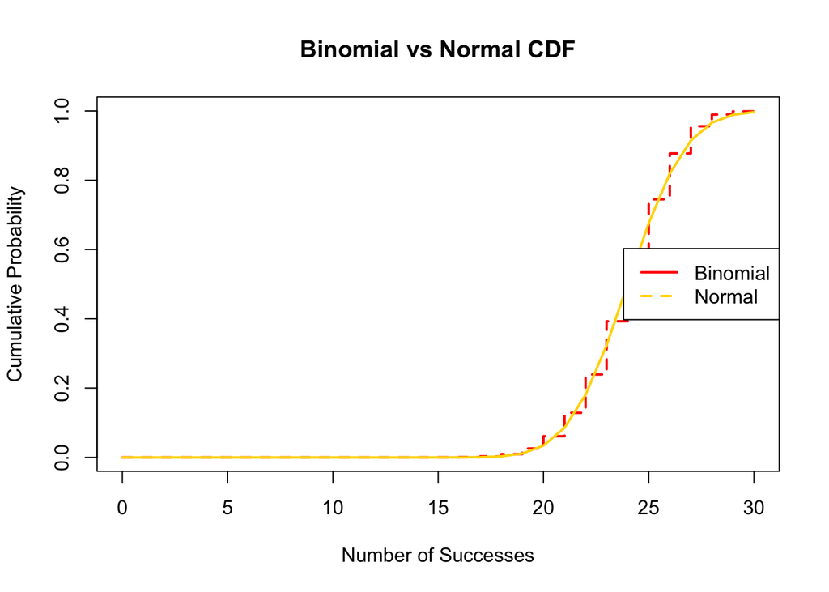

```r
# Case 2: np is large but n(1-p) < 10
plot_cdf(n = 30, p = 0.8)
```

In the second case, where np is large and n(1-p) < 10, the graphs don’t overlap as much.

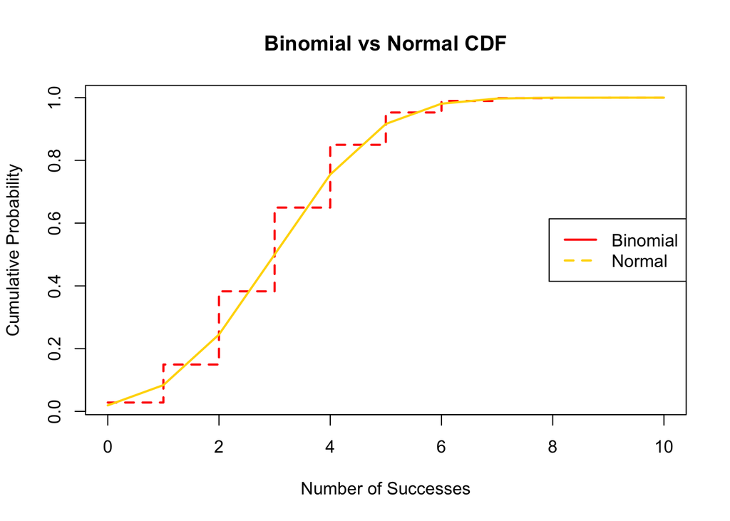

```r
# Case 3: np < 10 and n(1-p) < 10
plot_cdf(n = 10, p = 0.3)
```

Describe what happens in all three cases. In what sense are the cdf’s not close in cases 2 and 3? (Hint: Compare with a cdf of the normal distribution)

Cases 2 and 3 present distinct graph characteristics, featuring variations on a broader scale. Their overlap is notably reduced, and it’s worth noting that the binomial distribution’s cumulative distribution function (CDF) displays more significant step increments in case 3 compared to case 2.

## Problem-5

A graphical technique for checking whether a sample has an approximate normal distribution is a “quantile-quantile” plot. The **R** command is `qqnorm(x)`, where $x$ is the vector of sample values. If the plot is approximately a straight line, then this suggests that the sample comes from a normal distribution. Use the dataset from the `openintro` package to find out which of the the four distributions (three exams and course grade) is the closest to a normal distribution? You can load the dataset with the following commands `library(openintro)` and `data(exam_grades)`. Explore this by making `qqnorm()` and `qqline()` plots of the four distributions How close to straight lines are the plots in each case? How do the plots differ from straight lines? Hint: Make sure to remove the NA values.

```r
library(openintro)
data(exam_grades)
cleandata <- na.omit(exam_grades)
head(cleandata)
```

```
# A tibble: 6 × 6
  semester sex   exam1 exam2 exam3 course_grade
  <chr>    <chr> <dbl> <dbl> <dbl>        <dbl>
1 2000-1   Man    84.5  69.5  86.5         76.3
2 2000-1   Man    80    74    67           75.4
3 2000-1   Man    56    70    71.5         67.1
4 2000-1   Man    64    61    67.5         63.5
5 2000-1   Man    90.5  72.5  75           72.4
6 2000-1   Man    74    78.5  84.5         71.4
```

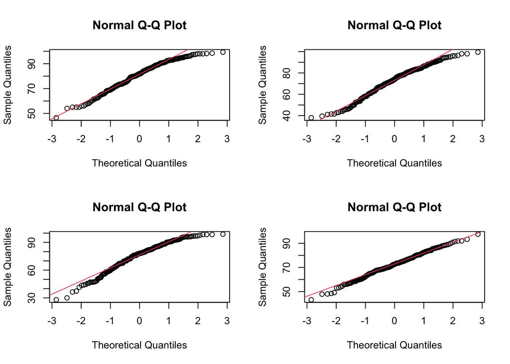

```r
par(mfrow = c(2,2))


qqnorm(cleandata$exam1)
qqline(cleandata$exam1, col = 2)

qqnorm(cleandata$exam2)
qqline(cleandata$exam2, col = 2)

qqnorm(cleandata$exam3)
qqline(cleandata$exam3, col = 2)

qqnorm(cleandata$course_grade)
qqline(cleandata$course_grade, col = 2)
```

## Problem-6

If $X$ has a continuous distribution with cumulative distribution function $F$, then the new random variable $U = F(X)$ has a uniform $U(0,1)$ distribution. Verify this with simulations for three different continuous distributions of your choice, by making a random sample of sufficient size, sorting it, plugging it into the cdf $F$, and plotting the result.

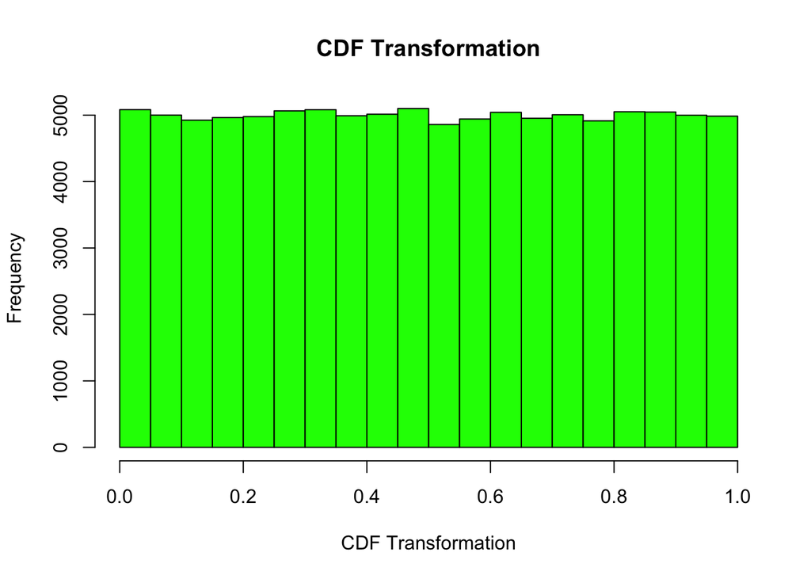

```r
set.seed(432)

expo <- rexp(100000, rate = 2)

expcdf <- pexp(expo, rate = 2)

hist(expcdf, main = "CDF Transformation", xlab = 'CDF Transformation', ylab = 'Frequency', col = 'green')
```

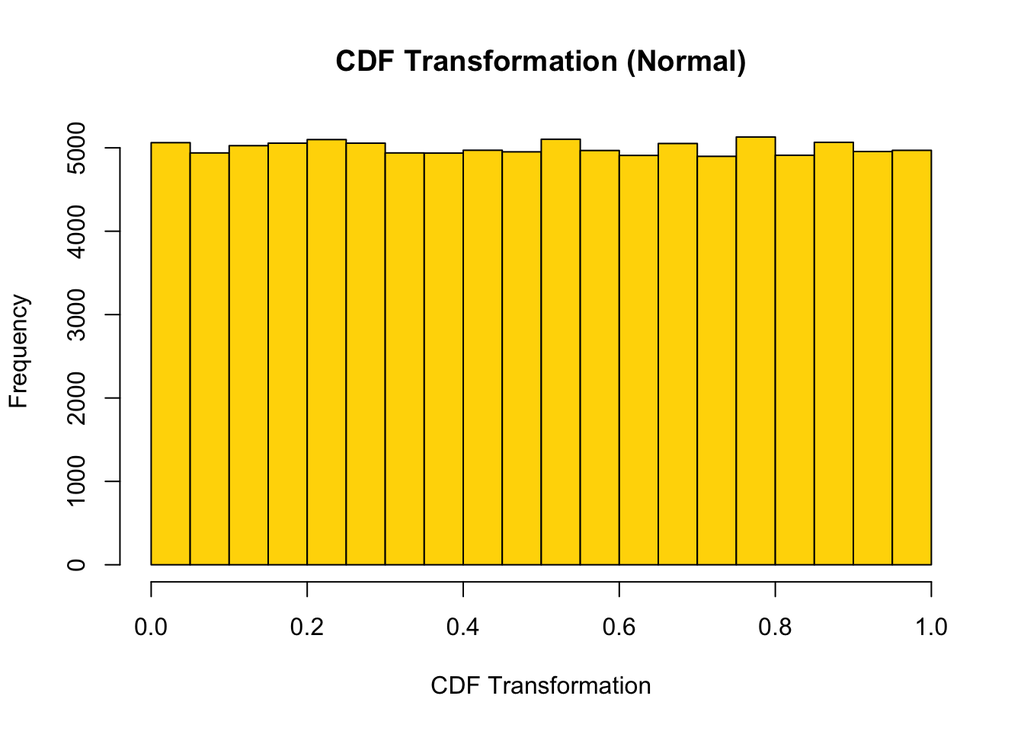

```r
normal <- rnorm(100000)

ncdft <- pnorm(normal)

hist(ncdft, main = "CDF Transformation (Normal)", xlab = "CDF Transformation", ylab = "Frequency", col = 'Gold')
```

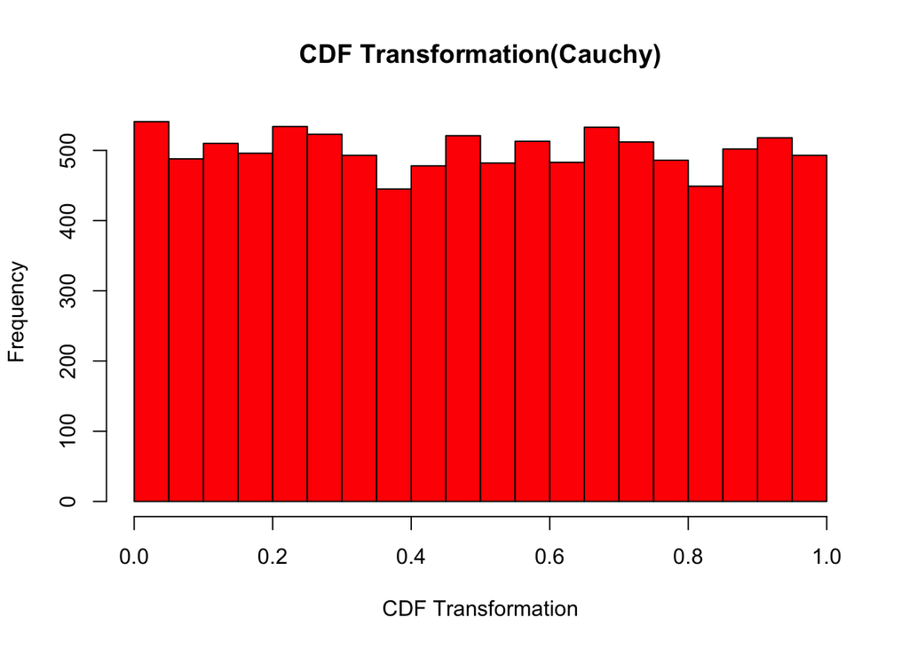

```r
csample <- rcauchy(10000)

ccdft <- pcauchy(csample)

hist(ccdft, main = "CDF Transformation(Cauchy)", xlab = 'CDF Transformation', ylab = 'Frequency', col = 'red')
```

## Optional additional problem

Suppose for $X = X_1 + X_2$ is the sum of two exponentially distributed random variables with the same parameter $\lambda$. Then $X^\alpha$ is very nearly normally distributed for a suitable choice of $\alpha$. Determine an approximate value for $\alpha$ (within 0.05), using a simulation and `qqnorm()` plots for each of your choices of $\alpha$.